# COMPSCIX 415.2 Homework 6

Yukio Rattai

```r
library(mdsr)
library(tidyverse)
library(mosaicData)
```

# Exercise 1

## 1. What variables are in this data set?

```r
colnames(Whickham)
```

```
## [1] "outcome"   "smoker"    "age"       "age_range"
```

## 2. How many observations are there and what does each represent?

```r
nrow(Whickham)
```

```
## [1] 1314
```

### according to the documentation for the data, there are 1314 observations, this can be verified by looking at the number of rows in the dataset.

## 3. Create a table (use the R code below as a guide) and a visualization of the relationship between smoking status and outcome, ignoring age. What do you see? Does it make sense?

```r
smoke_outcome <- Whickham %>% count( smoker, outcome )
smoke_outcome
```

```
## # A tibble: 4 x 3
##   smoker outcome     n
##   <fct>  <fct>   <int>
## 1 No     Alive     502
## 2 No     Dead      230
## 3 Yes    Alive     443
## 4 Yes    Dead      139
```

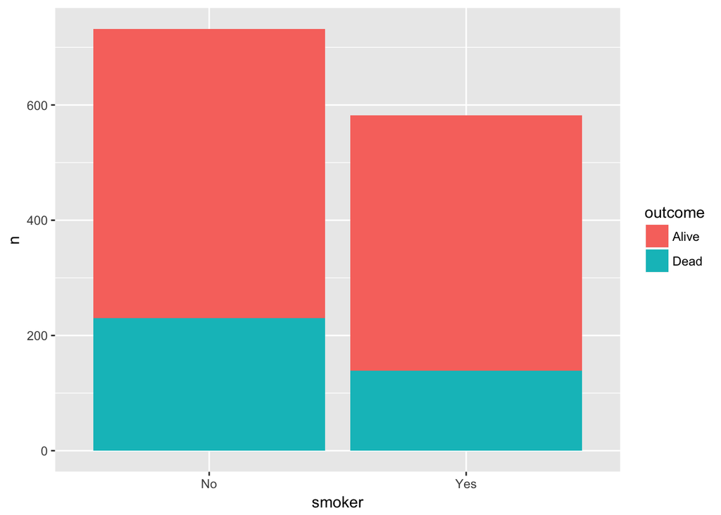

```r
ggplot(smoke_outcome) + geom_bar(aes(x = smoker, y = n, fill = outcome), stat = 'identity')
```

### It appears that there are more alive non-smokers than alive smokers in this data set (which may be expected)

### However, there are also less dead smokers than dead non-smokers in the data.

### It is hard to draw any conclusion by just looking at the count since there are more non-smokers than smokers reported in this data.

## 4. Recode the age variable into an ordered factor with three categories: age <= 44, age > 44 & age <= 64, and age > 64. Now, recreate visualization from above, but facet on your new age factor. What do you see? Does it make sense?

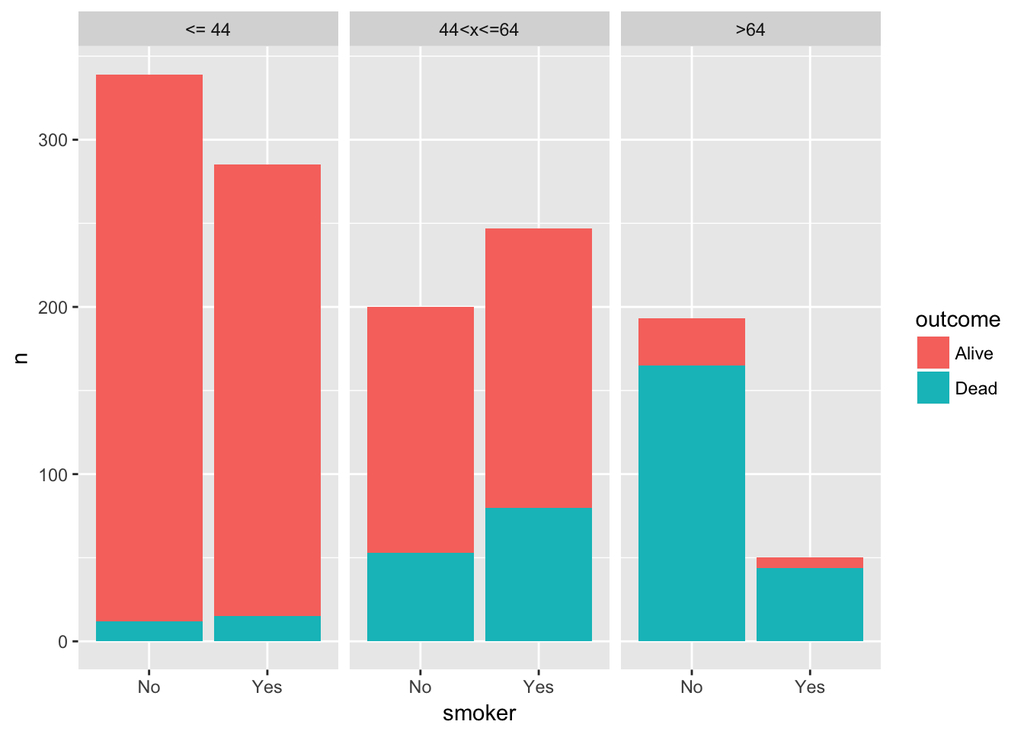

```r
Whickham$age_range <- case_when(Whickham$age <= 44 ~ '<= 44', Whickham$age > 44 & Whickham$age <= 64 ~ '44<x<=64', Whickham$age > 64 ~ '>64') %>% factor(ordered=TRUE, levels=c('<= 44','44<x<=64','>64'))

smoke_outcome <- Whickham %>% count( smoker, outcome, age_range )
ggplot(smoke_outcome) + geom_bar(aes(x = smoker, y = n, fill = outcome), stat = 'identity') +
  facet_grid(~ age_range)
```

### It looks like the mortality rate of smokers and non-smokers in the younger age group is very similar, however it appears that there are fewer smokers and they have a higher count of death.

### The middle age group has a slightly higher proportion of dead in the smoking group, compared to the non-smoking group.

### Looking at the over 64 age group. It looks like there are very few smokers of this age. And most of those who have been reported as smokers are also deceased

### It appears as if a persons smoking status is more predictive of their mortality as they age.

# Exercise 2

## 1. Generate a random sample of size n = 10000 from a gamma(1,2) distribution and plot a histogram or density curve. Use the code below to help you get your sample.

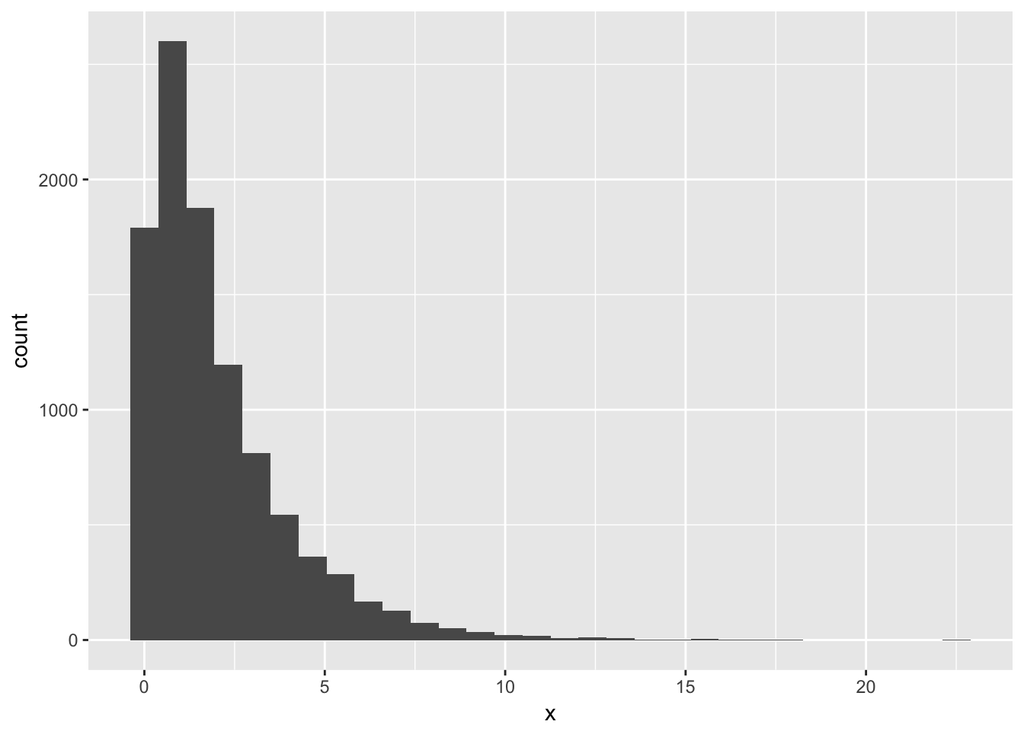

```r
n <- 10000
gamma_samp <- tibble(x = rgamma(n, shape = 1, scale = 2))

ggplot(gamma_samp) +
  geom_histogram(aes(x=x))
```

```r
#mean
mean_samp <- mean(gamma_samp$x)
mean_samp
```

```
## [1] 1.995522
```

```r
#standard deviation
sd_samp <- sd(gamma_samp$x)
sd_samp
```

```
## [1] 2.015565
```

## 3. Pretend the distribution of our population of data looks like the plot above. Now take a sample of size n = 30 from a Gamma(1,2) distribution, plot the histogram or density curve, and calculate the mean and standard deviation.

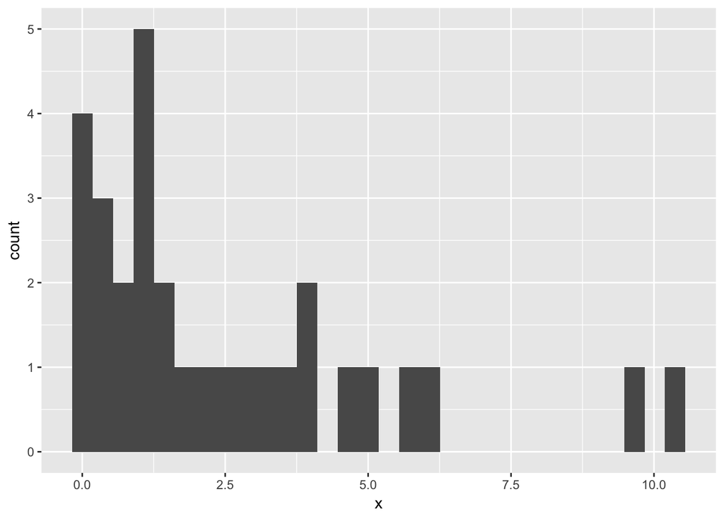

```r
n <- 30
gamma_samp <- tibble(x = rgamma(n, shape = 1, scale = 2))

ggplot(gamma_samp) +
  geom_histogram(aes(x=x))
```

```r
#mean
mean_samp <- mean(gamma_samp$x)
mean_samp
```

```
## [1] 2.538419
```

```r
#standard deviation
sd_samp <- sd(gamma_samp$x)
sd_samp
```

```
## [1] 2.679253
```

## 4. Take a sample of size n = 30, again from the Gamma(1,2) distribution, calculate the mean, and assign it to a vector named mean_samp. Repeat this 10000 times!!!! The code below might help.

```r
# create a vector with 10000 NAs
mean_samp <- rep(NA, 10000)

# start a loop
for(i in 1:10000) {
  g_samp <- rgamma(30, shape = 1, scale = 2)
  mean_samp[i] <- mean(g_samp)
}
# Convert vector to a tibble
mean_samp <- tibble(mean_samp)

mean_samp
```

```
## # A tibble: 10,000 x 1
##    mean_samp
##        <dbl>
##  1      2.46
##  2      1.88
##  3      3.04
##  4      2.02
##  5      2.54
##  6      2.41
##  7      1.63
##  8      2.37
##  9      2.23
## 10      2.21
## # ... with 9,990 more rows
```

## 5. Make a histogram of your collection of means from above (mean_samp).

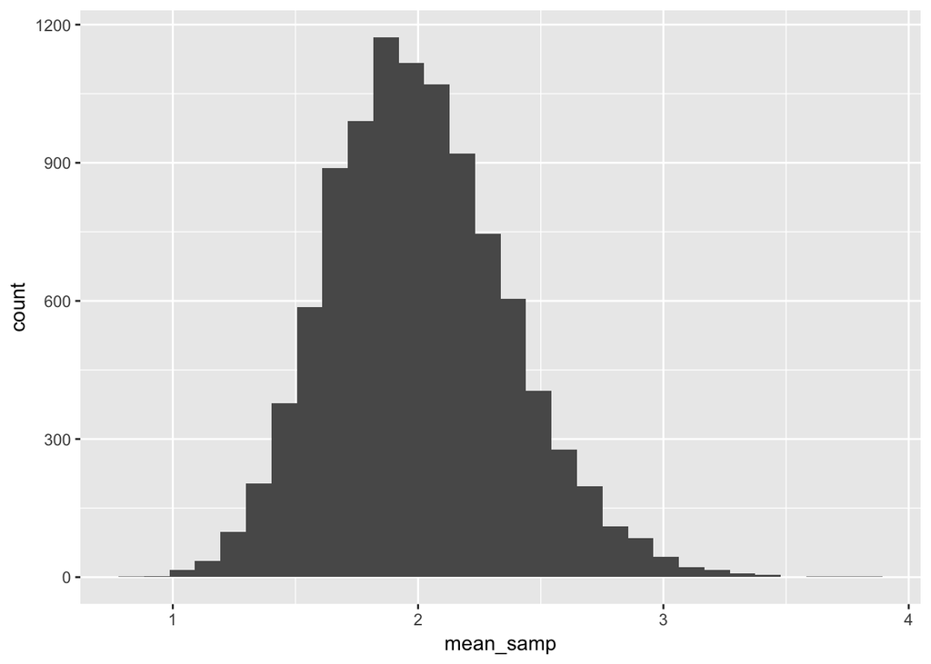

```r
ggplot(mean_samp) +
  geom_histogram(aes(x=mean_samp))
```

## 6. Calculate the mean and standard deviation of all of your sample means.

```r
#mean
mean(mean_samp$mean_samp)
```

```
## [1] 2.003613
```

```r
#standard deviation
sd(mean_samp$mean_samp)
```

```
## [1] 0.3651732
```

## 7. Did anything surprise you about your answers to #6?

### Without prior knowlege of the Central Limit Theorem, I would be surprised by the fact that the standard deviation is so low.

## 8. Repeat #4-#6, but now with a sample of size n = 300 instead. Do your results match up well with the theorem?

```r
# create a vector with 10000 NAs
mean_samp <- rep(NA, 10000)

# start a loop
for(i in 1:10000) {
  g_samp <- rgamma(300, shape = 1, scale = 2)
  mean_samp[i] <- mean(g_samp)
}
# Convert vector to a tibble
mean_samp <- tibble(mean_samp)

mean_samp
```

```
## # A tibble: 10,000 x 1
##    mean_samp
##        <dbl>
##  1      1.91
##  2      1.98
##  3      1.97
##  4      2.03
##  5      2.11
##  6      1.90
##  7      1.96
##  8      2.07
##  9      2.15
## 10      1.94
## # ... with 9,990 more rows
```

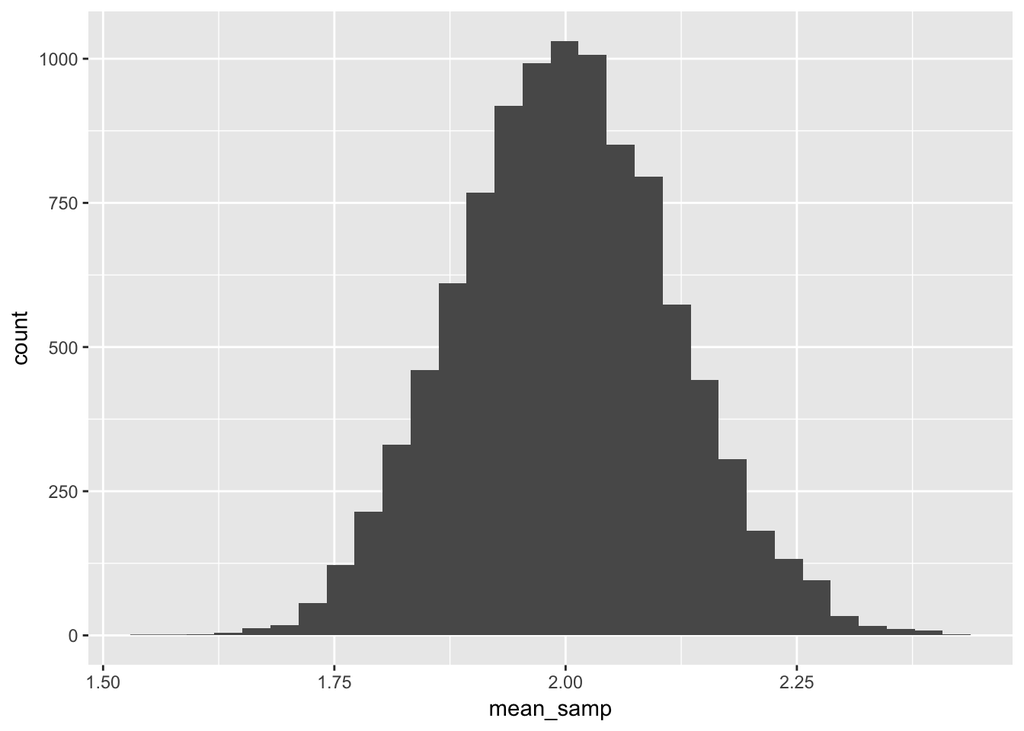

```r
ggplot(mean_samp) +
  geom_histogram(aes(x=mean_samp))
```

```r
#mean
mean_n_300 <- mean(mean_samp$mean_samp)
```

```r
#standard deviation
sd(mean_samp$mean_samp)
```

```
## [1] 0.1166093
```

## If we use the central limit theorem, we can approximate the standard deviation via the following calculation.

## It appears that the theorem holds in this case as well:

```r
mean_n_300/sqrt(300)
```

```
## [1] 0.115438
```